# Project 2D_Yayun Xu

### Scientific Question: Since the research shows that the MyD88-dependent TLR signaling pathway is most likely to be functional in terms of Mycobacterium Vaccae vaccine effect, is it possible for Mycobacterium Vaccae to have the same effect of stimulating human TLR signaling pathway?

Toll-like receptor 2 also known as TLR2 is a protein that in humans is encoded by the TLR2 gene. TLR2 is one of the toll-like receptors and plays a role in the immune system. TLR2 is a membrane protein, a receptor, which is expressed on the surface of certain cells and recognizes foreign substances and passes on appropriate signals to the cells of the immune system. (Rock et al., 1998)

TLR-mediated MyD88-dependent signaling pathway. MyD88 binds to the cytoplasmic portion of TLRs through interaction between individual TIR domains.(Takeda, 2004)

In a recent research, M. vaccae vaccination was shown to have a protection effect against M. tuberculosis infection. Further analysis pinpointed to the MyD88-dependent TLR signaling pathway and PI3K-Akt signaling pathway as most likely to be functional. doi: 10.1186/s40779-020-00258-4 https://www.ncbi.nlm.nih.gov/pmc/articles/PMC7268289/

Databases website:

NCBI: The National Center for Biotechnology Information (NCBI) provides a large suite of online resources for biological information and data, including the GenBank® nucleic acid sequence database and the PubMed database of citations and abstracts published in life science journals.

### Scientific Hypothesis: If the TLR2 receptor of humans is structurally similar to the TLR2 receptor of mice, Mycobacterium Vaccae vaccine might have the same effect of stimulating TLR signaling pathway in humans.

In addition, we will use homology sequence to get the protein structure of Human TLR2 and Mouse TLR2. We will get our protein sequences from NCBI website and download them as fasta file. Then we can use 3D protein measurement to compare different properties of the two species: amino acid sequence, secondary structure (hexlix, turn, and sheet), hydrophobicity.

If these properties are all similar, we could get to the conclusion that TLR2 receptor of humans is structurally similar to the TLR2 receptor of mice, and thus Mycobacterium Vaccae vaccine might have the same effect of stimulating TLR signaling pathway in huamans.

### Loading in Packages

```python
conda install -c bioconda mafft
```

[output not shown]

```python
conda install -c bioconda/label/cf201901 mafft
```

[output not shown]

```python
pip install logomaker
```

[output not shown]

```python
# Import libraries for Multiple Alignment
# Bio.Seq: This package provides objects to represent biological sequences with alphabets.
from Bio.Seq import Seq
# SeqIO: This pacakge provides a simple uniform interface to read and write sequences in various sequence file formats.
from Bio import SeqIO
# Bio.Align.Applications: This package provides Alignment command line tool wrappers like Mafft for multiple sequence alignment
from Bio.Align.Applications import MafftCommandline
# Bio.Align: This package imports multipleSeqAlignment for dealing with sequence alignments.
from Bio import AlignIO
from Bio.Align import MultipleSeqAlignment
# glob: This package finds all the pathnames matching a specified pattern, this allows me to read in all the fasta.
from glob import glob

# Import libraries for logomaker
# logomaker: This package is able generate publication-quality sequence logos from DNA, RNA, or protein sequences.
import logomaker as lm

# Import libraries for PDB
# Bio.PDB: This package allows us to read in pdb file and manipulate polypeptide structures.
from Bio.PDB import *
# nglview: This package provide functions to view molecular structures and trajectories.
import nglview as nv
# Bio.SeqUtils.ProtParam: This packages contains methods for protein analysis
from Bio.SeqUtils.ProtParam import ProteinAnalysis
```

```python
# Creating sample sequences
# Human
seq1 = SeqIO.read('gene_Human.fna', 'fasta')
# Mouse
seq2 = SeqIO.read('gene_Mouse.fna', 'fasta')

print(seq1)
print(seq2)

print(len(seq1.seq))
print(len(seq2.seq))
```

```
ID: NC_000004.12:153684280-153710637
Name: NC_000004.12:153684280-153710637
Description: NC_000004.12:153684280-153710637 TLR2 [organism=Homo sapiens] [GeneID=7097] [chromosome=4]
Number of features: 0
Seq('AGGCCGGCTCGGAGGCAGCGAGAAAGCGCAGCCAGGCGGCTGCTCGGCGTTCTC...TGA')
ID: NC_000069.7:c83749045-83743579
Name: NC_000069.7:c83749045-83743579
Description: NC_000069.7:c83749045-83743579 Tlr2 [organism=Mus musculus] [GeneID=24088] [chromosome=3]
Number of features: 0
Seq('GCCTGCCCTGTGGCTCCTGCCAGCTCTGATGCCAGGCTCCGTTCCCCTTGCAGA...GGA')
26358
5467
```

```python
# Pig
seq3 = SeqIO.read('/Users/hakuroku/BIMM143/gene_Human.fna', 'fasta')
# Dog
seq4 = SeqIO.read('/Users/hakuroku/BIMM143/gene_Dog.fna', 'fasta')

print(seq3)
print(seq4)

print(len(seq3.seq))
print(len(seq4.seq))
```

```
ID: NC_000004.12:153684280-153710637
Name: NC_000004.12:153684280-153710637
Description: NC_000004.12:153684280-153710637 TLR2 [organism=Homo sapiens] [GeneID=7097] [chromosome=4]
Number of features: 0
Seq('AGGCCGGCTCGGAGGCAGCGAGAAAGCGCAGCCAGGCGGCTGCTCGGCGTTCTC...TGA')
ID: NC_051819.1:52140775-52151566
Name: NC_051819.1:52140775-52151566
Description: NC_051819.1:52140775-52151566 TLR2 [organism=Canis lupus familiaris] [GeneID=448807] [chromosome=15]
Number of features: 0
Seq('CAGTTTGATTCTTAAAAGGTAGGTCGTCCCCCTTGTAAACATTCTTCACTAGTT...GAA')
26358
10792
```

### Performing Bioinformatics Analysis 1: Multiple Sequence Alignment

```python
# Read in sequence data from the fasta that was saved from the NCBI website.
for filename in glob('*.fna'):
    with open(filename) as f:
        # Create an empty file with the file name added with '-aligned.fna'.
        output = str(filename)
        output += '-aligned.fna'
        # The input for Mafft alignment is the string of the filename.
        in_file = str(filename)
        mafft_cline = MafftCommandline(input=in_file)
        stdout, stderr = mafft_cline()
        # Rewrite the output of the Mafft multiple sequence alignment results to the empty file that we created.
        with open(output, 'w') as handle:
            handle.write(stdout)
```

### Plotting the Results 1: Sequence Logos

Definition: A sequence logo is created from a collection of aligned sequences (from above) and depicts the consensus sequence and diversity of the sequences. It is a great way to visualize large amounts of DNA or protein sequences that share in common a conserved feature. To read the sequence logos, the larger the letter (which represents the bases of DNA sequences) is, the higher frequency the sequences share at the point.

```python
# Read the Mafft multiple sequence alignment results of Human TLR2 gene.
align_Human = AlignIO.read("gene_Human.fna-aligned.fna", "fasta")
# Read the Mafft multiple sequence alignment results of Mouse TLR2 gene.
align_Mouse = AlignIO.read("gene_Mouse.fna-aligned.fna", "fasta")
# Read the Mafft multiple sequence alignment results of Pig TLR2 gene.
align_Pig = AlignIO.read("gene_Pig.fna-aligned.fna", "fasta")
# Read the Mafft multiple sequence alignment results of Dog TLR2 gene.
align_Dog = AlignIO.read("gene_Dog.fna-aligned.fna", "fasta")

# Create a new list called align_list and add each alignment result to the list.
align_list = list()
align_list.append(str(align_Human[0].seq))
align_list.append(str(align_Mouse[0].seq))
align_list.append(str(align_Pig[0].seq))
align_list.append(str(align_Dog[0].seq))
# Print out the align_list to check.
print(align_list)
```

```
['aggccggctcggaggcagcgagaaagcgcagccaggcggctgctcggcgttctctcaggt…', 'gcctgccctgtggctcctgccagctctgatgccaggctccgttccccttgcagacccctg…', 'gcagaatttctaaaaagcagcttgtttcccttctgaacatgcctcacaggtttccgtggc…', 'cagtttgattcttaaaaggtaggtcgtcccccttgtaaacattcttcactagtttctgtg…']
```

```python
# Create a new list called SequenceLogos_list.
SequenceLogos_list = list()
# Extract and read the first 50 letters in each sequence in the align_list.
for a in align_list:
    first_50 = a[:50]
    SequenceLogos_list.append(first_50)
# Print out the SequenceLogos_list to check.
print(SequenceLogos_list)
```

```
['aggccggctcggaggcagcgagaaagcgcagccaggcggctgctcggcgt', 'gcctgccctgtggctcctgccagctctgatgccaggctccgttccccttg', 'gcagaatttctaaaaagcagcttgtttcccttctgaacatgcctcacagg', 'cagtttgattcttaaaaggtaggtcgtcccccttgtaaacattcttcact']
```

```
<logomaker.src.Logo.Logo at 0x7ff3914580d0>
```

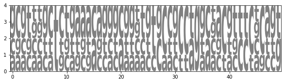

```python
# Display Sequence Logo.
# Create counts matrix.
Multi_counts_df = lm.alignment_to_matrix(sequences=SequenceLogos_list, to_type='counts', characters_to_ignore='.-X')
# Preview counts dataframe.
Multi_counts_df.head()
# Show full Multi counts.
lm.Logo(Multi_counts_df)
```

```python
# Create a new list called SequenceLogos_list2.
SequenceLogos_list2 = list()
# Extract and read the 1000th to 1050th letters in each sequence in the align_list.
for a in align_list:
    Middle_50 = a[1000:1050]
    SequenceLogos_list2.append(Middle_50)
# Print out the SequenceLogos2_list to check.
print(SequenceLogos_list2)
```

```
['acttaaatgcaagccaggaaagtctttttcctgtttgaaagagagagaaa', 'ggcttttgatctgacagaaagttcttcagcaaagagcaaatggtaggtaa', 'gggcggaatcgcagcgagggccggggggcgaggggaacttcgggatgcga', 'cggagaagcggggaagggtcgggattcggggtgtgcccatgcccaggagc']
```

```
<logomaker.src.Logo.Logo at 0x7ff3b301c100>
```

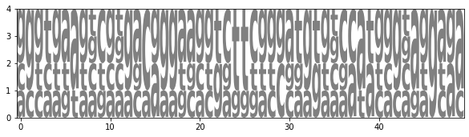

```python
# Display Sequence Logo.
# Create counts matrix.
Multi_counts_df = lm.alignment_to_matrix(sequences=SequenceLogos_list2, to_type='counts', characters_to_ignore='.-X')
# Preview counts dataframe.
Multi_counts_df.head()
# Show full Multi counts.
lm.Logo(Multi_counts_df)
```

### Performing Bioinformatics Analysis 2: Homology Sequence

Definition: Homology sequence is the situation where nucleic acid or protein sequences are similar because they have a common evolutionary origin. We want to figure out the functional similarity between Human TLR2 and Mouse TLR2 protein, so if they share common evolutionary origin, it is likely their protein structures are also alike.

```python
# Homology Sequence of Human TLR2.

# First, create a PDBParser object:
parser = PDBParser()
# Then, create a structure object from a PDB file in the following way (the PDB file in this case is called 1FAT.pdb, PHA-L is a user defined name for the structure):
Human_structure = parser.get_structure("Human_TLR2", "Human.pdb")
# View Biopython structural entities
view = nv.show_biopython(Human_structure)
view
```

https://swissmodel.expasy.org/templates/6nig.1

```python
# Homology Sequence of Mouse TLR2.

# First, create a PDBParser object:
parser = PDBParser()
# Then, create a structure object from a PDB file in the following way (the PDB file in this case is called 1FAT.pdb, PHA-L is a user defined name for the structure):
Mouse_structure = parser.get_structure("Mouse_TLR2", "Mouse.pdb")
# View Biopython structural entities
view = nv.show_biopython(Mouse_structure)
view
```

https://swissmodel.expasy.org/assess/6KZaUV/02

Biounit Oligo State Homo-dimer

QSQE 0.50

Method X-ray, 2.35 Å

Seq Similarity 0.48

Coverage 0.69

Range 27-544

### Plotting the Results: 3D Protein Measurement

Protein structure is the three-dimensional arrangement of atoms in an amino acid-chain molecule. With the results from homology sequence, we can visualize the 3D protein structures of Human and Mouse TLR2 and thus could determine the structural differences.

```python
# Polypeptide of Human sequence
polypeptide_builder = CaPPBuilder()
counter = 1
# Print out the polypeptide of Human TLR2 sequence.
for polypeptide in polypeptide_builder.build_peptides(Human_structure):
    Human_seq = polypeptide.get_sequence()
    print(f"Sequence: {counter}, Length: {len(Human_seq)}")
    print(Human_seq)
    counter += 1
```

```
Sequence: 1, Length: 218
SLSCDRNGICKGSSGSLNSIPSGLTEAVKSLDLSNNRITYISNSDLQRCVNLQALVLTSN…
Sequence: 2, Length: 328
NSLIKKFTFRNVKITDESLFQVMKLLNQISGLLELEFDDCTLNGVGNFRASDNDRVIDPG…
Sequence: 3, Length: 273
SLSCDRNGICKGSSGSLNSIPSGLTEAVKSLDLSNNRITYISNSDLQRCVNLQALVLTSN…
Sequence: 4, Length: 272
IDPGKVETLTIRRLHIPRFYLFYDLSTLYSLTERVKRITVENSKVFLVPCLLSQHLKSLE…
```

```python
# Define the polypeptide as analyzed_seq
analyzed_seq = ProteinAnalysis(str(Human_seq))
```

```python
# Analyze Human amino acid sequence.
analyzed_seq.get_amino_acids_percent()
```

```
{'A': 0.01838235294117647,
 'C': 0.029411764705882353,
 'D': 0.04044117647058824,
 'E': 0.05514705882352941,
 'F': 0.022058823529411766,
 'G': 0.025735294117647058,
 'H': 0.022058823529411766,
 'I': 0.0625,
 'K': 0.07352941176470588,
 'L': 0.17279411764705882,
 'M': 0.01838235294117647,
 'N': 0.0661764705882353,
 'P': 0.05514705882352941,
 'Q': 0.03308823529411765,
 'R': 0.04779411764705882,
 'S': 0.10661764705882353,
 'T': 0.0625,
 'V': 0.04044117647058824,
 'W': 0.01838235294117647,
 'Y': 0.029411764705882353}
```

```python
# Analyze the secondary structure of human sequence. The three results represent hexlix, turn, and sheet.
analyzed_seq.secondary_structure_fraction()
```

```
(0.34558823529411764, 0.2536764705882353, 0.2647058823529412)
```

```python
# Analyze the hydrophobicity.
analyzed_seq.gravy()
```

```
-0.22573529411764706
```

```python
# Polypeptide of Mouse sequence
polypeptide_builder = CaPPBuilder()
counter = 1
# Print out the polypeptide of Mouse TLR2 sequence.
for polypeptide in polypeptide_builder.build_peptides(Mouse_structure):
    Mouse_seq = polypeptide.get_sequence()
    print(f"Sequence: {counter}, Length: {len(Mouse_seq)}")
    print(Mouse_seq)
    counter += 1
```

```
Sequence: 1, Length: 518
SLSCDASGVCDGRSRSFTSIPSGLTAAMKSLDLSFNKITYIGHGDLRACANLQVLMLKSS…
```

```python
# Define the polypeptide as analyzed_seq
analyzed_seq = ProteinAnalysis(str(Mouse_seq))
```

```python
# Analyzing Mouse amino acids sequence
analyzed_seq.get_amino_acids_percent()
```

```
{'A': 0.032818532818532815,
 'C': 0.019305019305019305,
 'D': 0.05019305019305019,
 'E': 0.06177606177606178,
 'F': 0.055984555984555984,
 'G': 0.04054054054054054,
 'H': 0.021235521235521235,
 'I': 0.0444015444015444,
 'K': 0.04826254826254826,
 'L': 0.17374517374517376,
 'M': 0.017374517374517374,
 'N': 0.05405405405405406,
 'P': 0.03667953667953668,
 'Q': 0.02895752895752896,
 'R': 0.04633204633204633,
 'S': 0.12934362934362933,
 'T': 0.055984555984555984,
 'V': 0.05405405405405406,
 'W': 0.005791505791505791,
 'Y': 0.023166023166023165}
```

```python
# Analyze the secondary structure of Mouse sequence. The three results represent hexlix, turn, and sheet.
analyzed_seq.secondary_structure_fraction()
```

```
(0.3571428571428571, 0.26061776061776065, 0.2857142857142857)
```

```python
# Analyze the hydrophobicity.
analyzed_seq.gravy()
```

```
-0.01583011583011585
```